# Weight Lifting Exercises

ircus

February 13, 2016

The goal of this analysis is to predict the manner in which the participants did the Unilateral Dumbbell Biceps Curl.

Six young health participants were asked to perform one set of 10 repetitions of the exercise in five different fashions:

- exactly according to the specification (Class A),
- throwing the elbows to the front (Class B),
- lifting the dumbbell only halfway (Class C),
- lowering the dumbbell only halfway (Class D),
- and throwing the hips to the front (Class E).

The raw data to predict the quality class was collected using an on-body sensing approach. Spatial data from four sensors was recorded during the excercise: Belt, Arm, Forearm, Dumbbell.

I loaded the dataset into a **dt** data frame and removed all additional summary statistics variables, as I would like to base my prediction purely on the raw spatial data, I also removed the time variables and names, because I am not going to apply time modelling techniques, and the model I will obtain must not depend on the person who performed the task.

Since we are not limited in data at all and there are no computation time requirements, it would be a good idea to go with an algorithm that is time-consuming and requires a lot of data, but gives high accuracy in return.

One of the best choises in this case is the **Random Forests** model. Additionally I would like to use the regularization technique to limit down the number of predictors that will remain in the model to simplify it and avoid overfitting. Therefore, the model I will fit is **Regularized Random Forests** from the *RRF* package.

Moreover, to estimate the out of sample error I will use **Cross-Validation** on 10 folds created by means of the *caret* package, and as my best fitted model select the one that produced the highest accuracy on its fold’s testing portion.

```r
set.seed(123)
folds = createFolds(dt$classe, k = 10)

for (i in 1:length(folds)) {
  train=dt[-folds[[i]],]
  test=dt[folds[[i]],]

  fit = RRF(x=train[-53],
            y=train$classe,
            ntree = 10,
            replace = FALSE)
  pred=predict(fit, test)

  acc = confusionMatrix(pred, test$classe)$overall[1]
  accSum = accSum + acc
  if (acc>bestAcc) {
    bestFit = fit
    bestAcc = acc
  }
}
```

The described process obtains the following measures:

```
##    OutOfSampleError OutOfSampleAccuracy     BestFitAccuracy
##          0.01269017          0.98730983          0.99184921
```

And the **20** features that got selected during training are as follows, ordered by importance according to the mean decrease in Gini coefficient, which is a measure of how each variable contributes to the resulting random forest.

```r
featSetImp = cbind("MeanDecreaseGini"=sort(bestFit$importance[bestFit$importance[,1]!=0,], decreasing = TRUE))
print(featSetImp)
```

```
##                   MeanDecreaseGini
## roll_belt               1596.61438
## yaw_belt                1232.61578
## pitch_forearm            870.50945
## magnet_dumbbell_z        857.39782
## magnet_dumbbell_x        805.71092
## pitch_belt               483.75076
## yaw_arm                  392.35473
## accel_dumbbell_z         390.81588
## magnet_belt_x            364.85873
## roll_forearm             334.02989
## accel_belt_z             254.10072
## accel_forearm_x          224.93510
## pitch_dumbbell           172.19254
## yaw_forearm              148.79682
## accel_forearm_y          116.69208
## accel_forearm_z          113.60656
## accel_arm_y              107.23299
## gyros_arm_x               91.71271
## total_accel_belt          80.41365
## pitch_arm                 78.59140
```

Let’s see how do the two most important features correspond to each other:

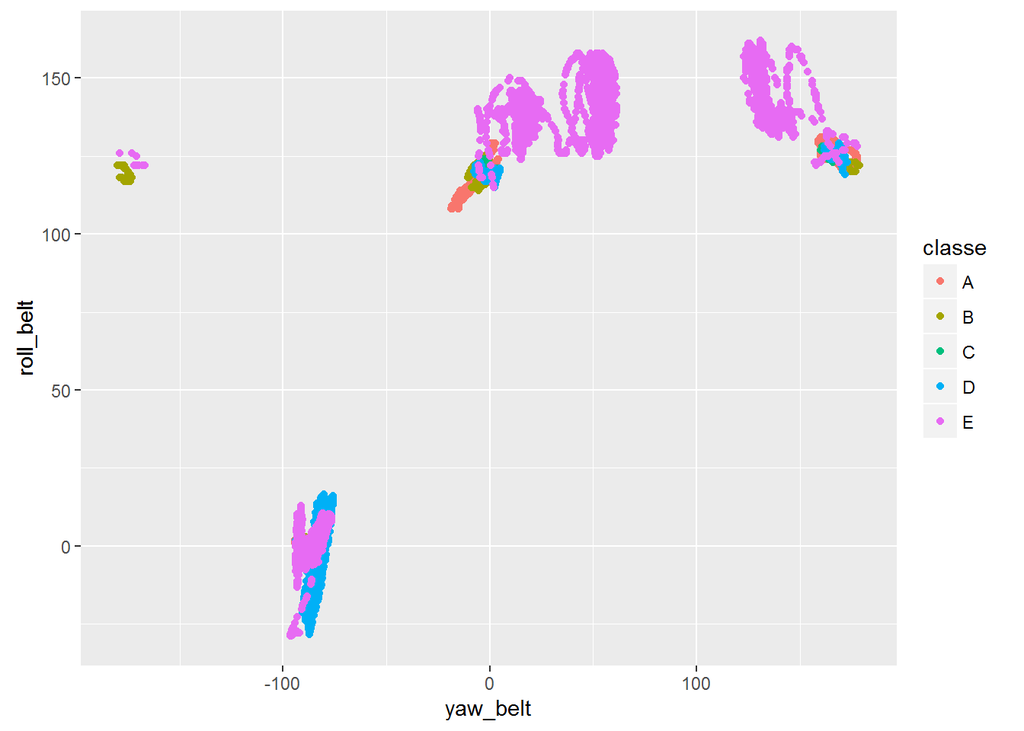

```r
library(ggplot2)
qplot(yaw_belt, roll_belt, data=dt, col=classe)
```

Now I will load the test set in a **cases** data frame and predict the classes of the sample there.

```r
predict(bestFit, cases)
```

```
##  1  2  3  4  5  6  7  8  9 10 11 12 13 14 15 16 17 18 19 20
##  B  A  B  A  A  E  D  B  A  A  B  C  B  A  E  E  A  B  B  B
## Levels: A B C D E
```